# Final Project – Harmonic Analysis on Grid-connected Bridge Inverter (with Unipolar Modulation)

Author

Qiaoxuan Zhang

Published

June 30, 2026

## Objective

The objective of this experiment is to design, implement, and analyse a **single-phase full-bridge inverter** in MATLAB/Simulink using **unipolar sinusoidal pulse-width modulation (SPWM)**. Specifically, the report aims to:

1. Build and verify the Simulink model with a resistive load, both without and with a filter inductor $L_f$.
2. Examine the inverter output voltage $V_{ab}$ on the resistive load and its Fast Fourier Transform (FFT) spectrum under both conditions.
3. Evaluate the voltage waveform across the resistive load and its Total Harmonic Distortion (THD) when $L_f$ is present.
4. Compare the harmonic performance of unipolar SPWM against square wave modulation.
5. Extend the model to grid-connected operation and verify the steady-state phasor relationship between the inverter output voltage, the filter inductor voltage, and the grid voltage.
6. Measure the grid current waveform and its THD.

Key simulation parameters are summarised in Table 1.

Table 1: Simulation parameters.

[output not shown]

## Simulink Model — Unipolar SPWM with Resistive Load

### Without Filter Inductor

In this configuration the filter inductor is not included and only a resistive load is connected between the bridge midpoints. This allows the raw, unfiltered $V_{ab}$ waveform to be captured for FFT analysis.

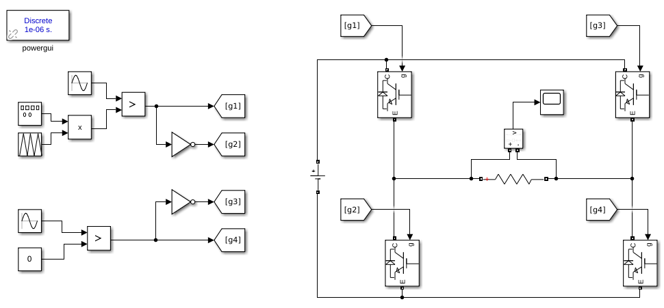

Figure 1: Simulink model with resistive load and no filter inductor (right side). Gate signals g1–g4 are generated by the unipolar SPWM subsystem (left side). The voltage measurement block probes $V_{ab}$ directly.

### With Filter Inductor ($L_f$ in circuit)

The filter inductor $L_f$ is connected in series to the resistive load. The voltage scope is placed to measure the waveform output of the actual load voltage after filtering.

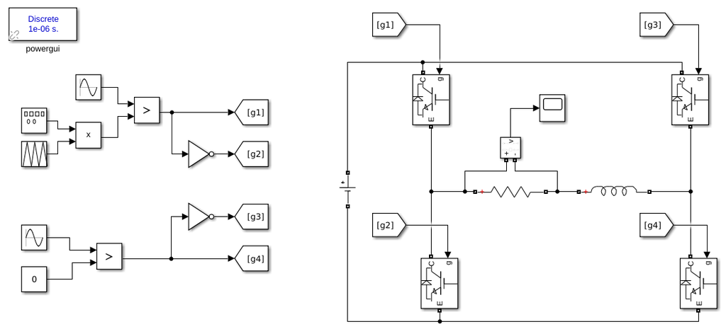

Figure 2: Simulink model with filter inductor $L_f$ added in series with the resistive load. The voltage scope is tapped across $R$ only.

## Output Voltage Waveform and FFT Analysis

### Without Filter Inductor

Without $L_f$, the bridge output voltage $V_{ab}$ is a three-level switching waveform.

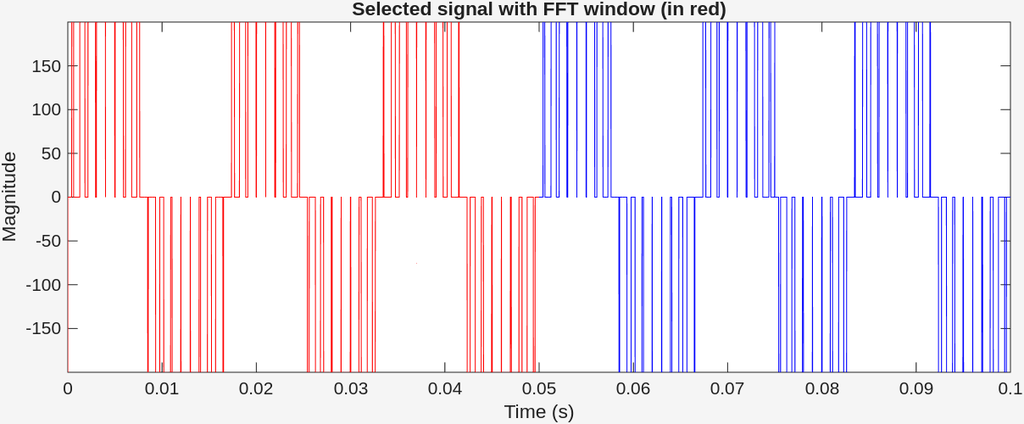

Figure 3: Time-domain waveform of $V_{ab}$ without the filter inductor, showing the characteristic three-level unipolar switching pattern.

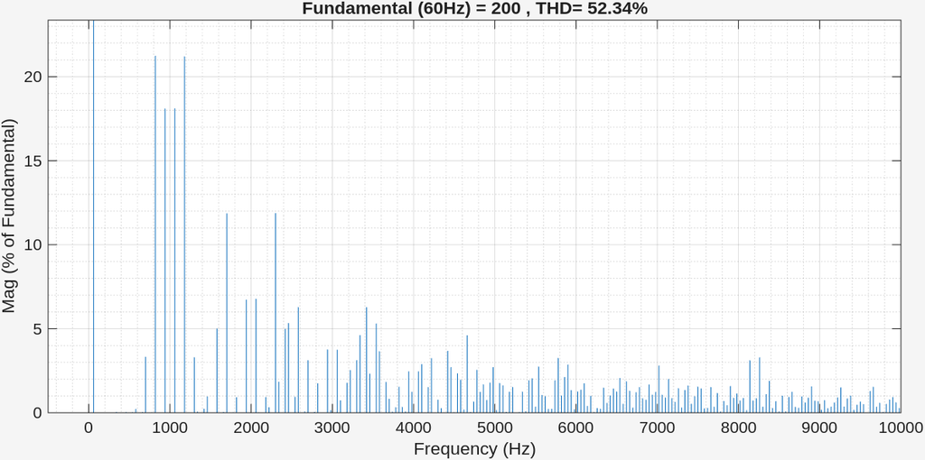

### With Filter Inductor

With $L_f$ reconnected, the inductor acts as a low-pass filter and attenuates the high-frequency harmonic content. The load voltage across $R$ approaches a sinusoidal waveform.

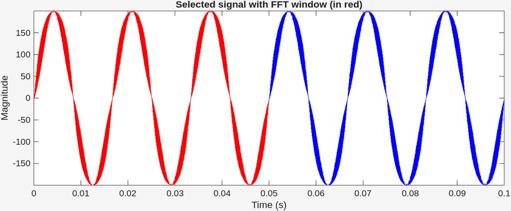

Figure 5: Voltage waveform across the resistive load with $L_f$ in circuit. The waveform is substantially more sinusoidal than $V_{ab}$ without the filter.

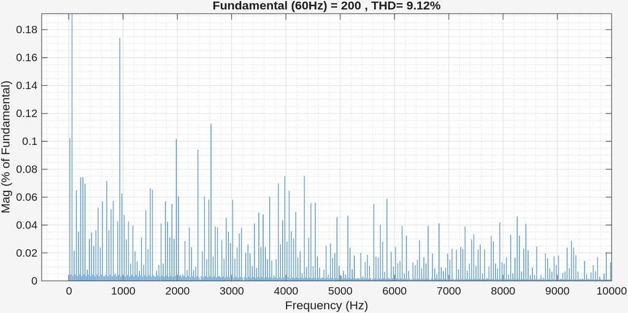

Figure 6: FFT / THD analysis of the load voltage with $L_f$, from the Simulink Powergui FFT Analysis tool.

## Comparison with Square Wave Modulation

To benchmark harmonic performance, the gate-signal generator was replaced with a simple square-wave source operating at the fundamental frequency $f_1$. In this scheme, S1 and S4 conduct simultaneously during the positive half-cycle while S2 and S3 conduct during the negative half-cycle, producing a two-level output ($+V_{dc}$ / $-V_{dc}$) with no carrier modulation, as shown in Figure 7 on the left side.

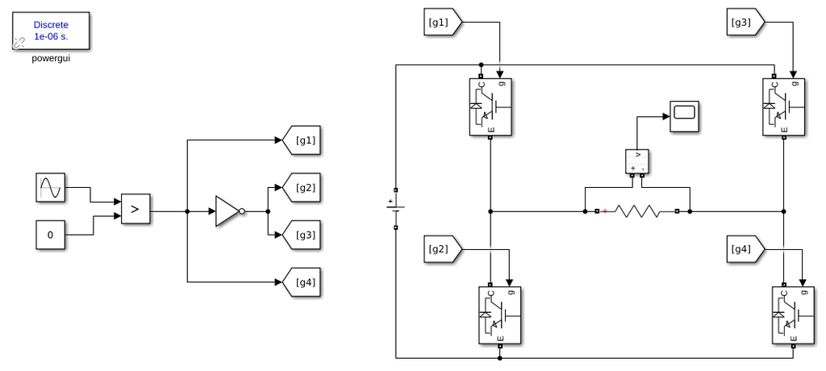

The output voltage waveform is a simple square wave, and the FFT spectrum shows significant low-order harmonic content, with the harmonics of 60 Hz, 180 Hz, 300 Hz, etc., corresponding to 1st, 3rd, 5th, etc. harmonics of the fundamental frequency. The THD is approximately 48.3%, which is higher than that of unipolar SPWM with filtering.

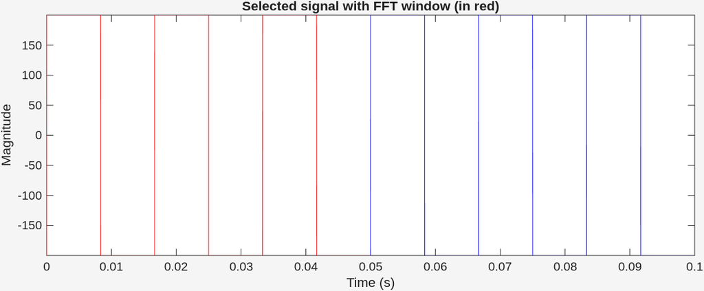

Figure 8: Voltage waveform across the resistive load under square-wave switching. The waveform is a simple two-level square wave, with significant low-order harmonic content.

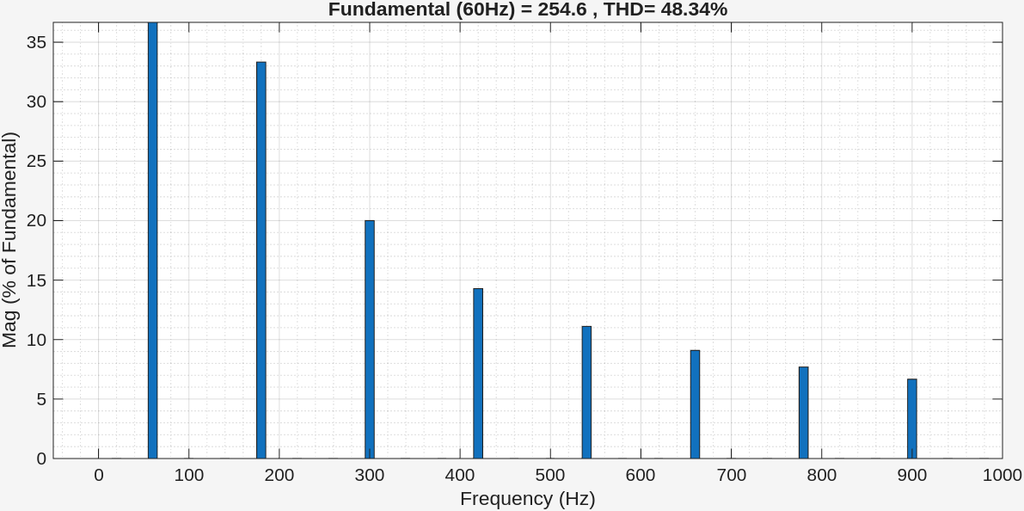

## Simulink Model — Grid-Connected Operation

In the grid-connected configuration the resistive load is replaced by an AC grid voltage source $V_g$ connected through the filter inductor $L_f$. The inverter must synthesise an output voltage $V_{ab}$ whose amplitude and phase are determined by the grid voltage and the desired injected current.

### Steady-State Phasor Analysis

[figure not shown]

Figure 10: Circuit diagram of the grid-connected inverter with filter inductor $L_f$ and grid voltage source $V_g$. The inverter output voltage $V_{ab}$ is measured across the series combination of $L_f$ and $V_g$.

The KVL equation around the output loop (Figure 10) gives:

$$V_{ab} = V_L + V_g
\tag{1}$$

where $V_L = j\omega I_{L_f} L_f$ is the phasor voltage across the filter inductor.

[figure not shown]

Figure 11: Phasor diagram showing the relationship between the grid voltage $V_g$, the inductor voltage $V_L$, and the inverter output voltage $V_{ab}$. The angle $\theta$ represents the phase lead of $V_{ab}$ over $V_g$.

The grid voltage phasor (in phase with $I_{L_f}$ for a resistive grid equivalent) is:

$$V_g = 120\sqrt{2} \approx 169.68\angle 0°\;\text{V}
\tag{3}$$

Because $V_L \perp V_g$ in the phasor diagram (Figure 11), the required inverter output amplitude is:

$$V_{ab} = \sqrt{V_L^2 + V_g^2}
= \sqrt{3.77^2 + 169.68^2}
= \sqrt{14.21 + 28\,791.38}
\approx 169.722\;\text{V}
\tag{4}$$

The corresponding phase lead of $V_{ab}$ over $V_g$ is:

$$\theta = \arctan\!\left(\frac{V_L}{V_g}\right)
= \arctan\!\left(\frac{3.77}{169.68}\right)
\approx 0.0222\;\text{rad}
\equiv 1.2728°
\tag{5}$$

Finally, the modulation index required to produce this output from a $V_{dc} = 200\;\text{V}$ DC bus is:

$$\boxed{m_a = \frac{|V_{ab}|}{V_{dc}}
= \frac{169.722}{200}
\approx 0.84861}
\tag{6}$$

### Simulink Model Screenshots

The sinusoidal reference amplitude and phase offset were set in the unipolar SPWM subsystem (top-left in Figure 12) to match the phasor analysis results in Steady-State Phasor Analysis. The current measurement block was placed in series with $L_f$ to probe the grid current waveform.

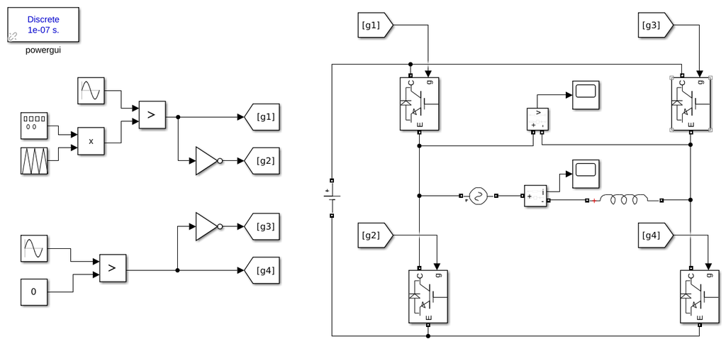

Figure 12: Top-level Simulink model for grid-connected operation. The series path from the bridge output is: $L_f$ → current measurement block → AC voltage source $V_g$. The current scope is a series ammeter block, not a parallel voltage measurement.

Waveforms were captured from the current scope, showing the grid current $i_g(t)$ in phase with the grid voltage $V_g$ for unity power-factor injection. The THD of the grid current was measured to be approximately 13%, indicating that the inverter is effectively injecting a nearly sinusoidal current into the grid.

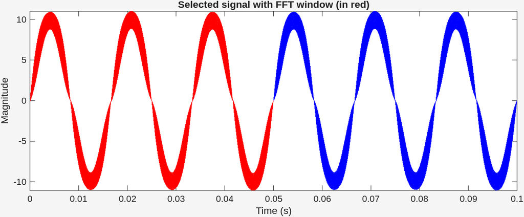

Figure 13: Grid current waveform $i_g(t)$ (in Amphere) with $L_f$ in circuit. The waveform is approximately sinusoidal and in phase with $V_g$ for unity power-factor injection.

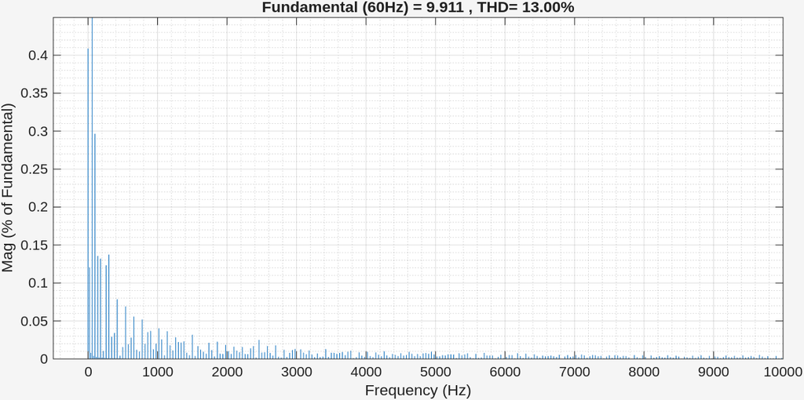

Figure 14: FFT / THD analysis of the grid current from the Simulink Powergui FFT Analysis tool.

## Conclusion

The phasor analysis in Steady-State Phasor Analysis showed that the inverter output voltage $V_{ab}$ must lead the grid voltage $V_g$ by a small angle $\theta \approx 1.2728°$ to drive the desired grid current $I_{L_f}$. The required modulation index was calculated to be approximately $0.84861$. The Simulink model for grid-connected operation confirmed that the grid current waveform was approximately sinusoidal and in phase with the grid voltage, with a THD of about 13%, indicating effective harmonic performance.